# COVID-Whole Child Equity Index

LD

June 16, 2020

**Goal** Explore the correlation between COVID-19 cases and the Whole Child Equity Index.

```r
options(scipen = 999)
library(RPostgreSQL)
library(rpostgis)
library(data.table)
library(sf)
library(dplyr)
library(foreign)
library(tidycensus)
library(data.table)


# cb_root <- "W:/Base/CBF/census_2018_cartographic_boundary_files/"
covidroot <- "W:/Project/RDA Team/COVID Whole Child/"

#loads the PostgreSQL driver
drv <- dbDriver("PostgreSQL")


# create connection
con <- dbConnect(drv, dbname = "covid19_race_class",
                 host = "aws-postgres-db.c5udgz7ro8hq.us-west-2.rds.amazonaws.com", port = 5432,
                 user = "postgres", password = "password")



# create connection
con_wc <- dbConnect(drv, dbname = "whole_child",
                 host = "aws-postgres-db.c5udgz7ro8hq.us-west-2.rds.amazonaws.com", port = 5432,
                 user = "postgres", password = "password")

# create connection
conRDA <- dbConnect(drv, dbname = "rda_shared_data",
                 host = "aws-postgres-db.c5udgz7ro8hq.us-west-2.rds.amazonaws.com", port = 5432,
                 user = "postgres", password = "password")
```

# Part I. Methods

## Load and prepare data

### Load most recent COVID layer

Query PostgreSQL db

```r
covid <- st_read(con, query = "SELECT DISTINCT ON (lacounty_covid_case_rate_place_data.lac_place_name) lacounty_covid_case_rate_place_data.lac_place_name,
    lacounty_covid_case_rate_place_data.date,
    lacounty_covid_case_rate_place_data.confirmed_cases,
    lacounty_covid_case_rate_place_data.cases_per100k,
    lacounty_covid_case_rate_place_data.total_population,
    lacounty_covid_case_rate_place_data.nh_white_pct,
    lacounty_covid_case_rate_place_data.nh_black_pct,
    lacounty_covid_case_rate_place_data.nh_asian_pct,
    lacounty_covid_case_rate_place_data.latino_pct,
    lacounty_covid_case_rate_place_data.nh_nhpi_pct,
    lacounty_covid_case_rate_place_data.nh_aian_pct,
    lacounty_covid_case_rate_place_data.nh_white_quantiles,
    lacounty_covid_case_rate_place_data.nh_black_quantiles,
    lacounty_covid_case_rate_place_data.nh_asian_quantiles,
    lacounty_covid_case_rate_place_data.latino_quantiles,
    lacounty_covid_case_rate_place_data.nh_aian_quantiles,
    lacounty_covid_case_rate_place_data.nh_nhpi_quantiles,
    lacounty_covid_case_rate_place_data.geom
   FROM lacounty_covid_case_rate_place_data
  WHERE lacounty_covid_case_rate_place_data.lac_place_name IS NOT NULL
  ORDER BY lacounty_covid_case_rate_place_data.lac_place_name, lacounty_covid_case_rate_place_data.date DESC")
```

### Load Whole Child Equity Index

```r
# load equity index draft, query pumas in la county only
wc_ind <- st_read(con_wc, query="SELECT puma_id, est_num_chil0_8, quintiles, equityindex_ranks, rankingtype
                  FROM step4_wc_equity_index
                  WHERE puma_id like '037%'")

head(wc_ind)
```

```
##   puma_id est_num_chil0_8 quintiles equityindex_ranks rankingtype
## 1   03701           15064         3               129    Moderate
## 2   03702           24231         3               156    Moderate
## 3   03703           22519         1                 1     Highest
## 4   03704           25001         1                42     Highest
## 5   03705           16644         4               160         Low
## 6   03706           15353         3               117    Moderate
```

```r
dim(wc_ind) # 69 pumas in LA County
```

```
## [1] 69  5
```

### Load PUMA geometries

- Load PUMAs shapes, subset LA County PUMAs and project to SRID 3310.

```r
# load puma boundaries (cb)
puma <- st_read(conRDA, c("geographies_ca", "cb_2017_06_puma10_500k"))

puma <- subset(puma, pumace10 %like% "037")

# project
puma <- st_transform(puma, 3310) # match the covid neighborhood projection
dim(puma) # 69 pumas
```

```
## [1] 69 10
```

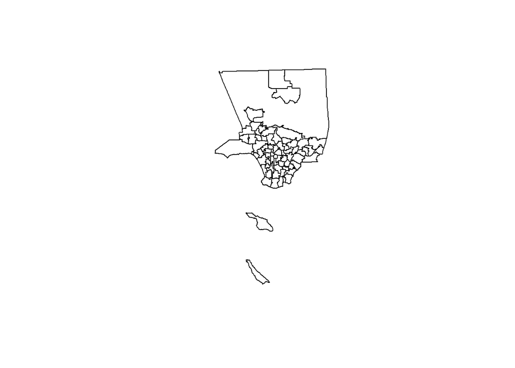

```r
# test plot
plot(puma$geom)
```

### Join the WC Index to PUMA Geographies

Make whole child index spatial

```r
## Join indicators to PUMA geometries
wc_sp <- full_join(puma, wc_ind, by=c("pumace10"="puma_id"))

dim(wc_sp) # same number of rows post-join
```

```
## [1] 69 14
```

```r
#head(wc_sp) # looks good
```

## Create PUMA - COVID Crosswalk

COVID neighborhoods do not conform to tracts or other census geographies.

The neighborhoods being used for COVID are smaller than PUMAs (there are ~304 neighborhoods vs. 69 PUMAs). The goal is to crosswalk neighborhoods to PUMAs and then aggregate COVID cases to PUMAs.

### Step 1. Intersect PUMAs and COVID Neighborhood geometries

Prepare for intersect: Calculate area of COVID neighborhoods

```r
# calc area of covid sp area
covid$area_neighb <- st_area(covid)

# calculate area of pumas
puma$area_puma <- st_area(puma)

# st_write(covid, "covid_polys.geojson", driver = "GeoJSON")
# st_write(puma, "puma_polys.geojson", driver = "GeoJSON")

# st_write(covid, "covid_polys.shp", driver = "ESRI Shapefile")
# st_write(puma, "puma_polys.shp", driver = "ESRI Shapefile")
```

Intersect COVID And PUMAs

```r
# intersect
int <- st_intersection(covid, puma)
```

### Step 2. Calculate area of intersecting polygons

```r
# calc area of intersect
int$area_int <- st_area(int)
```

### Step 3. Calculate percent overlap of intersecting area with tract

How much of the neighborhood intersects with the PUMA?

EX: If 50% of the neighborhood intersects with a PUMA, that PUMA gets 50% of their COVID cases.

```r
# % intersect
int$prc_int <- as.numeric(int$area_int/int$area_neighb)
```

Review – Example:

- All of Norwalk is within the PUMA 03755 (Los Angeles County (Southeast)–Norwalk City).
- there are some small slivers of Norwalk intersecting with other PUMAs, but nothing significant (less than 1% of Norwalk’s area)

```r
# just look at one tract and some columns
# int[int$pumace10 =="03766",]
#
# int[int$lac_place_name =="Long Beach",]

int[int$lac_place_name %like% "Norwalk", c(1:3, 21, 24, 28,  31)]
```

```
## Simple feature collection with 4 features and 7 fields
## geometry type:  GEOMETRY
## dimension:      XY
## bbox:           xmin: 174623.4 ymin: -457673.9 xmax: 181097.6 ymax: -451752.2
## epsg (SRID):    3310
## proj4string:    +proj=aea +lat_1=34 +lat_2=40.5 +lat_0=0 +lon_0=-120 +x_0=0 +y_0=-4000000 +ellps=GRS80 +towgs84=0,0,0,0,0,0,0 +units=m +no_defs
##       lac_place_name       date confirmed_cases pumace10
## 132          Norwalk 2020-06-10             652    03753
## 132.1        Norwalk 2020-06-10             652    03764
## 132.2        Norwalk 2020-06-10             652    03755
## 132.3        Norwalk 2020-06-10             652    03754
##                                                                                  name10
## 132                                             Los Angeles County (South)--Downey City
## 132.1 Los Angeles County (South)--Lakewood, Cerritos, Artesia & Hawaiian Gardens Cities
## 132.2                                      Los Angeles County (Southeast)--Norwalk City
## 132.3               Los Angeles County (Southeast)--La Mirada & Santa Fe Springs Cities
##            area_puma      prc_int                           geom
## 132   31738777 [m^2] 0.0003901993 MULTIPOLYGON (((174690.1 -4...
## 132.1 53956093 [m^2] 0.0005464268 MULTIPOLYGON (((176775.7 -4...
## 132.2 30242070 [m^2] 0.9972873536 POLYGON ((177414.9 -457641....
## 132.3 61324428 [m^2] 0.0017760203 MULTIPOLYGON (((176594.3 -4...
```

- PUMA 03755 (Los Angeles County (Southeast)–Norwalk City ) is mostly made up of Norwalk, but also has some area from Bellflower and Downey.
- This PUMA will get about 100% of cases from Norwalk, 25% of cases from Bellflower, and 2.5% of cases from Downey. The rest are slivers.

```r
int[int$pumace10 =="03755", c(1:3, 21, 24, 28,  31)]
```

```
## Simple feature collection with 6 features and 7 fields
## geometry type:  GEOMETRY
## dimension:      XY
## bbox:           xmin: 172567.5 ymin: -458086 xmax: 181091.6 ymax: -450603.9
## epsg (SRID):    3310
## proj4string:    +proj=aea +lat_1=34 +lat_2=40.5 +lat_0=0 +lon_0=-120 +x_0=0 +y_0=-4000000 +ellps=GRS80 +towgs84=0,0,0,0,0,0,0 +units=m +no_defs
##         lac_place_name       date confirmed_cases pumace10
## 8.1            Artesia 2020-06-10              49    03755
## 15.3        Bellflower 2020-06-10             503    03755
## 32.1          Cerritos 2020-06-10             144    03755
## 48.3            Downey 2020-06-10             923    03755
## 132.2          Norwalk 2020-06-10             652    03755
## 165.1 Santa Fe Springs 2020-06-10              92    03755
##                                             name10      area_puma
## 8.1   Los Angeles County (Southeast)--Norwalk City 30242070 [m^2]
## 15.3  Los Angeles County (Southeast)--Norwalk City 30242070 [m^2]
## 32.1  Los Angeles County (Southeast)--Norwalk City 30242070 [m^2]
## 48.3  Los Angeles County (Southeast)--Norwalk City 30242070 [m^2]
## 132.2 Los Angeles County (Southeast)--Norwalk City 30242070 [m^2]
## 165.1 Los Angeles County (Southeast)--Norwalk City 30242070 [m^2]
##            prc_int                           geom
## 8.1   0.0001685409 POLYGON ((176913.4 -457655....
## 15.3  0.2485443342 POLYGON ((172567.6 -454480....
## 32.1  0.0012913597 MULTIPOLYGON (((178287.5 -4...
## 48.3  0.0255440370 MULTIPOLYGON (((174690.1 -4...
## 132.2 0.9972873536 POLYGON ((177414.9 -457641....
## 165.1 0.0053211522 MULTIPOLYGON (((179569.6 -4...
```

### Map this one tract and the intersecting neighborhoods:

The PUMA geom is red, COVID neighborhoods black outline.

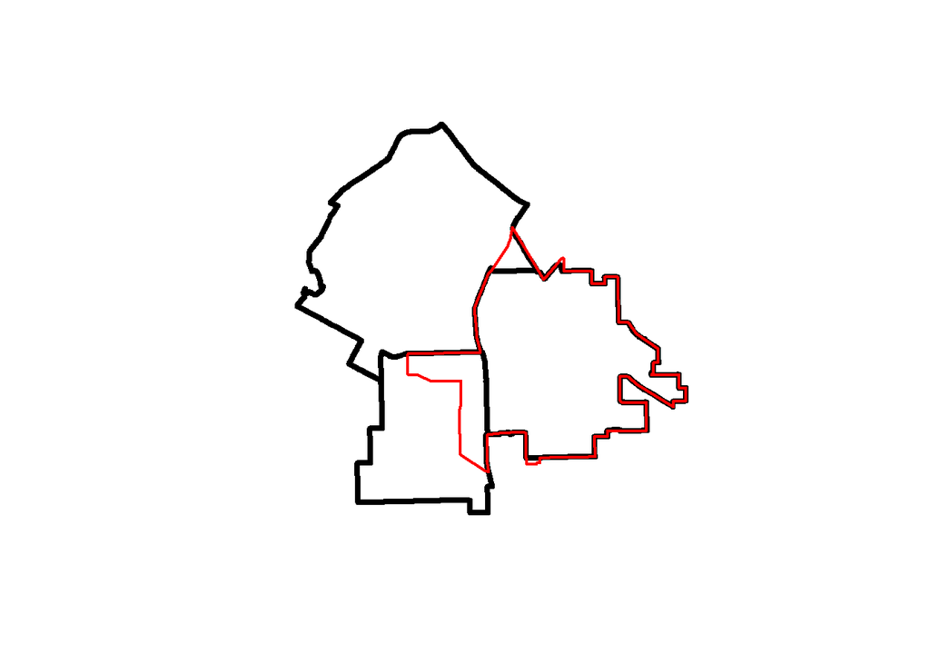

```r
plot(covid[covid$lac_place_name %in% c("Bellflower", "Downey", "Norwalk"),]$geom, lwd=4)
plot(puma[puma$pumace10 =="03755",]$geom, border="red", lwd=2, add=T)
```

### Step 4. Export crosswalk file here:

```r
xwalk <-
int %>%
  as.data.frame() %>%
  select(lac_place_name, pumace10, geoid10, name10, area_puma, area_neighb, area_int, prc_int)

write.csv(xwalk, paste0(covidroot, "Data/lac_place_puma_xwalk.csv"), row.names = FALSE)
```

## Proportional Allocation of COVID Cases

### Step 1. Join Crosswalk and Multiply Cases by % Intersect

```r
# join crosswalk to covid cases
covid_xwalk <-
covid %>%
  as.data.frame() %>%
  select(-area_neighb) %>%

  # join crosswalk
  full_join(xwalk, by="lac_place_name") %>%

  # multiply prc intersect to covid cases
  mutate(prop_cases = confirmed_cases * prc_int)

# review
head(covid_xwalk[, c(1:3, 19:26)])
```

```
##    lac_place_name       date confirmed_cases pumace10 geoid10
## 1 Adams-Normandie 2020-06-10              60    03746 0603746
## 2    Agoura Hills 2020-06-10              36    03726 0603726
## 3        Alhambra 2020-06-10             256    03735 0603735
## 4        Alhambra 2020-06-10             256    03736 0603736
## 5        Alhambra 2020-06-10             256    03717 0603717
## 6        Alhambra 2020-06-10             256    03737 0603737
##                                                                                 name10
## 1 Los Angeles County--LA City (Central/Univ. of Southern California & Exposition Park)
## 2        Los Angeles County--Calabasas, Agoura Hills, Malibu & Westlake Village Cities
## 3        Los Angeles County--LA City (Mount Washington, Highland Park & Glassell Park)
## 4                       Los Angeles County (Central)--Alhambra & South Pasadena Cities
## 5         Los Angeles County (East Central)--Arcadia, San Gabriel & Temple City Cities
## 6                        Los Angeles County (Central)--Monterey Park & Rosemead Cities
##         area_puma      area_neighb          area_int      prc_int
## 1  14324084 [m^2]   960786.9 [m^2]   960786.89 [m^2] 1.0000000000
## 2 477436776 [m^2] 20249072.7 [m^2] 20246458.34 [m^2] 0.9998708907
## 3  50264742 [m^2] 19766894.9 [m^2]    11687.94 [m^2] 0.0005912888
## 4  29929514 [m^2] 19766894.9 [m^2] 19717292.33 [m^2] 0.9974906241
## 5  72805273 [m^2] 19766894.9 [m^2]    24909.77 [m^2] 0.0012601764
## 6  38167017 [m^2] 19766894.9 [m^2]    13004.85 [m^2] 0.0006579108
##    prop_cases
## 1  60.0000000
## 2  35.9953521
## 3   0.1513699
## 4 255.3575998
## 5   0.3226052
## 6   0.1684252
```

#### Review Norwalk example

Most cases from Norwalk are assigned to PUMA 03755

```r
covid_xwalk[covid_xwalk$lac_place_name %like% "Norwalk", c(1:3, 19:21, 25, 26)]
```

```
##     lac_place_name       date confirmed_cases pumace10 geoid10
## 414        Norwalk 2020-06-10             652    03753 0603753
## 415        Norwalk 2020-06-10             652    03764 0603764
## 416        Norwalk 2020-06-10             652    03755 0603755
## 417        Norwalk 2020-06-10             652    03754 0603754
##                                                                                name10
## 414                                           Los Angeles County (South)--Downey City
## 415 Los Angeles County (South)--Lakewood, Cerritos, Artesia & Hawaiian Gardens Cities
## 416                                      Los Angeles County (Southeast)--Norwalk City
## 417               Los Angeles County (Southeast)--La Mirada & Santa Fe Springs Cities
##          prc_int  prop_cases
## 414 0.0003901993   0.2544100
## 415 0.0005464268   0.3562703
## 416 0.9972873536 650.2313545
## 417 0.0017760203   1.1579652
```

### Step 2. Summarize COVID cases by PUMA

The number of COVID cases in a community have been proportionally allocated to PUMAs. Sum cases by PUMA.

```r
cases_puma <-
covid_xwalk %>%
  group_by(pumace10, geoid10, name10) %>%
  summarize(sum_cases = sum(prop_cases, na.rm = T))

head(cases_puma)
```

```
## # A tibble: 6 x 4
## # Groups:   pumace10, geoid10 [6]
##   pumace10 geoid10 name10                                         sum_cases
##   <chr>    <chr>   <chr>                                              <dbl>
## 1 03701    0603701 Los Angeles County (North/Unincorporated)--Ca~     2221.
## 2 03702    0603702 Los Angeles County (Northwest)--Santa Clarita~      726.
## 3 03703    0603703 Los Angeles County (North Central)--Lancaster~      636.
## 4 03704    0603704 Los Angeles County (North Central)--Palmdale ~      662.
## 5 03705    0603705 Los Angeles County (North)--LA City (Northwes~     1098.
## 6 03706    0603706 Los Angeles County (North)--LA City (North Ce~     1320.
```

#### Review

Review the Norwalk example. Here we see Norwalk ends up with 800 covid cases.

```r
cases_puma[cases_puma$name10 %like% "Norwalk", ]
```

```
## # A tibble: 1 x 4
## # Groups:   pumace10, geoid10 [1]
##   pumace10 geoid10 name10                                       sum_cases
##   <chr>    <chr>   <chr>                                            <dbl>
## 1 03755    0603755 Los Angeles County (Southeast)--Norwalk City      800.
```

Looking at the map below, the (red) Norwalk PUMA should have 100% of Norwalk cases, and some (smaller) proportions of Bellflower and Downey cases.

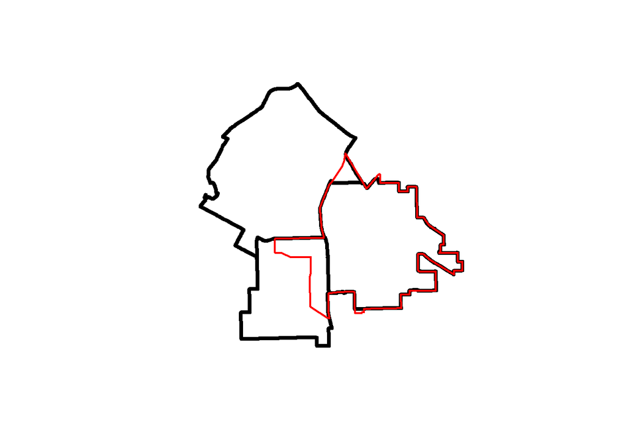

```r
plot(covid[covid$lac_place_name %in% c("Bellflower", "Downey", "Norwalk"),]$geom, lwd=4)
plot(puma[puma$pumace10 =="03755",]$geom, border="red", lwd=2, add=T)
```

Looking at the original covid data, Norwalk has a total of 652 COVID cases, and Bellflower and Downey each have 500+ and 900+ cases. So Norwalk ending up with 800 cases seems reasonable.

```r
covid[covid$lac_place_name %in% c("Bellflower", "Downey", "Norwalk"), 1:3]
```

```
## Simple feature collection with 3 features and 3 fields
## geometry type:  POLYGON
## dimension:      XY
## bbox:           xmin: 169180.6 ymin: -459350.8 xmax: 181097.6 ymax: -447447.4
## epsg (SRID):    3310
## proj4string:    +proj=aea +lat_1=34 +lat_2=40.5 +lat_0=0 +lon_0=-120 +x_0=0 +y_0=-4000000 +ellps=GRS80 +towgs84=0,0,0,0,0,0,0 +units=m +no_defs
##     lac_place_name       date confirmed_cases
## 15      Bellflower 2020-06-10             503
## 48          Downey 2020-06-10             923
## 132        Norwalk 2020-06-10             652
##                               geom
## 15  POLYGON ((175052.8 -458086,...
## 48  POLYGON ((174657.1 -453630....
## 132 POLYGON ((177414.9 -457641....
```

### Map COVID Cases by PUMA

See if COVID/PUMA mapping looks reasonable.

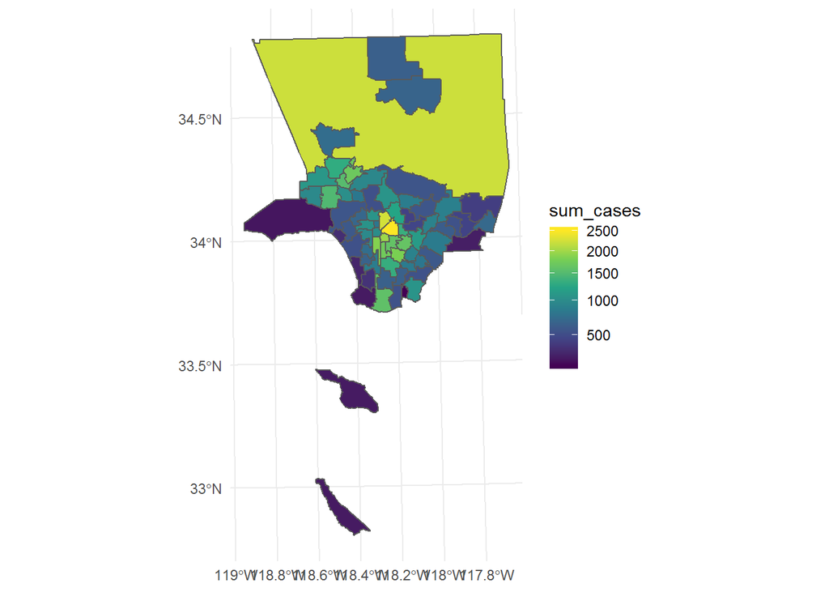

```r
library(ggplot2)

cases_puma_sp <- full_join(puma, cases_puma)

ggplot(data = cases_puma_sp) +
    geom_sf() +
    geom_sf(data = cases_puma_sp, aes(fill = sum_cases)) +
    scale_fill_viridis_c(trans = "sqrt") +
  theme_minimal()
```

# Part II. Plot Results

## Test Different Typologies & Plot

Going to test some different options for typologies.

First join Whole Child index to COVID cases by PUMA:

```r
# head(wc_ind)

wc_covid <-
  cases_puma %>%
  full_join(wc_ind, by=c("pumace10" = "puma_id"))

head(wc_covid)
```

```
## # A tibble: 6 x 8
## # Groups:   pumace10, geoid10 [6]
##   pumace10 geoid10 name10 sum_cases est_num_chil0_8 quintiles
##   <chr>    <chr>   <chr>      <dbl>           <dbl>     <int>
## 1 03701    0603701 Los A~     2221.           15064         3
## 2 03702    0603702 Los A~      726.           24231         3
## 3 03703    0603703 Los A~      636.           22519         1
## 4 03704    0603704 Los A~      662.           25001         1
## 5 03705    0603705 Los A~     1098.           16644         4
## 6 03706    0603706 Los A~     1320.           15353         3
## # ... with 2 more variables: equityindex_ranks <dbl>, rankingtype <chr>
```

```r
# summary(wc_covid)
# dim(wc_covid)
```

### Quick basic diagnostic to verify the data tells us what we expect:

```r
corr_eqrank <- cor.test(wc_covid$sum_cases, wc_covid$equityindex_ranks)

corr_eqrank
```

```
##
##  Pearson's product-moment correlation
##
## data:  wc_covid$sum_cases and wc_covid$equityindex_ranks
## t = -4.5211, df = 67, p-value = 0.00002572
## alternative hypothesis: true correlation is not equal to 0
## 95 percent confidence interval:
##  -0.6462240 -0.2787055
## sample estimates:
##       cor
## -0.483493
```

- Correlation of -0.48 is a fairly strong negative correlation between COVID cases and equity ranks. Since equity rank = 1 is the highest need, a negative correlation means that as COVID cases increase, equity rank decreases–indicates higher need.
- Also we see this correlation is statistically significant.

### Typology Test 1

Use existing Whole Child type rankings (highes to lowest), grouped into three categories.

```r
# group quintiles
wc_covid$group_rank <- ifelse(wc_covid$rankingtype %in% c("Highest", "High"),
                              "High/Highest",
                              ifelse(wc_covid$rankingtype %in% c("Lowest", "Low"),
                                     "Low/Lowest", wc_covid$rankingtype))


# summarize -- get average and median by groups
dat_grp <-
wc_covid %>%
  group_by(group_rank) %>%
  summarize(mean = mean(sum_cases, na.rm = T),
            median = median(sum_cases, na.rm = T))

dat_grp
```

```
## # A tibble: 3 x 3
##   group_rank    mean median
##   <chr>        <dbl>  <dbl>
## 1 High/Highest 1143.   987.
## 2 Low/Lowest    591.   541.
## 3 Moderate      836.   768.
```

#### Plot: COVID case density by grouped rankings

Overall, PUMAs with the lowest need are more likely to be areas with lower COVID cases. PUMAs with highest need are more likely to be areas with higher COVID cases.

- Average COVID case count for PUMAs with high/highest Whole Child ranking is 1,143.3, **1.9 times higher than the average COVID case count for PUMAs with the low/lowest Whole Child ranking.**
- The average number of COVID cases for PUMAs with moderate Whole Child ranking is 835.8, **1.4 times higher than the average COVID case count for PUMAs with the low/lowest Whole Child ranking.**

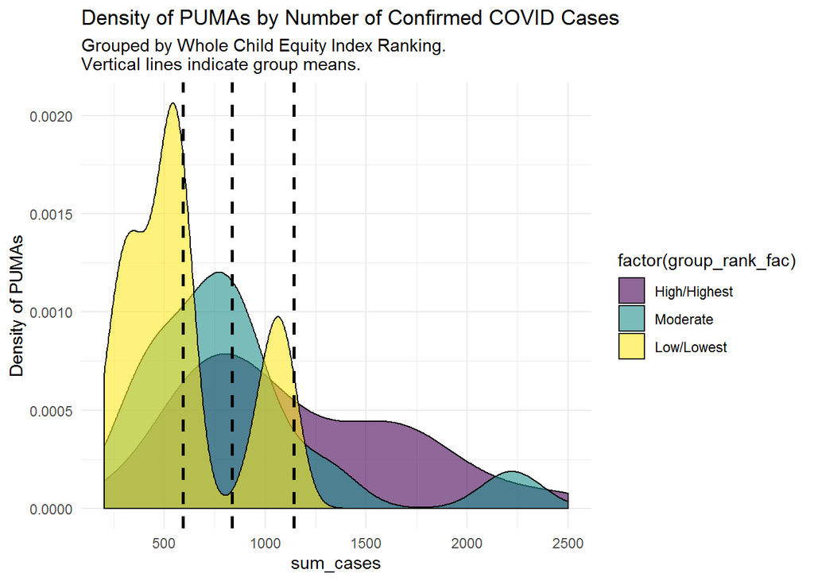

```r
# make grouped ranks ordered factors
wc_covid$group_rank_fac <- factor(wc_covid$group_rank, ordered = TRUE,
                                   levels = c("High/Highest", "Moderate", "Low/Lowest"))

# plot grouped ranks
ggplot(wc_covid, aes(sum_cases)) +
  geom_density(aes(fill=factor(group_rank_fac)), alpha = 0.6)+
   geom_vline(data = dat_grp, aes(xintercept = mean), linetype="dashed", size=1) +
  labs(title = "Density of PUMAs by Number of Confirmed COVID Cases",
       subtitle = "Grouped by Whole Child Equity Index Ranking.\nVertical lines indicate group means.") +
  ylab("Density of PUMAs") +
  theme_minimal()
```

### Typology Test 2: density by overall ranking

Use statewide equity rankings–look at covid cases in top half vs. bottom half.

- Median for overall (statewide) equity ranks is 81–half of PUMAs have a equity rank above/below 81

```r
summary(wc_covid$equityindex_ranks)
```

```
##    Min. 1st Qu.  Median    Mean 3rd Qu.    Max.
##    1.00   32.00   81.00   96.35  159.00  231.00
```

#### Plot

```r
wc_covid$equityindex_ranks_grp <- ifelse(wc_covid$equityindex_ranks <= 81, "Higher need",
                                         "Lower need")

dat_eqgrp <-
  wc_covid %>%
  group_by(equityindex_ranks_grp) %>%
  summarize(mean = mean(sum_cases, na.rm = T),
            median = median(sum_cases, na.rm = T))

dat_eqgrp
```

```
## # A tibble: 2 x 3
##   equityindex_ranks_grp  mean median
##   <chr>                 <dbl>  <dbl>
## 1 Higher need           1137.   971.
## 2 Lower need             748.   586.
```

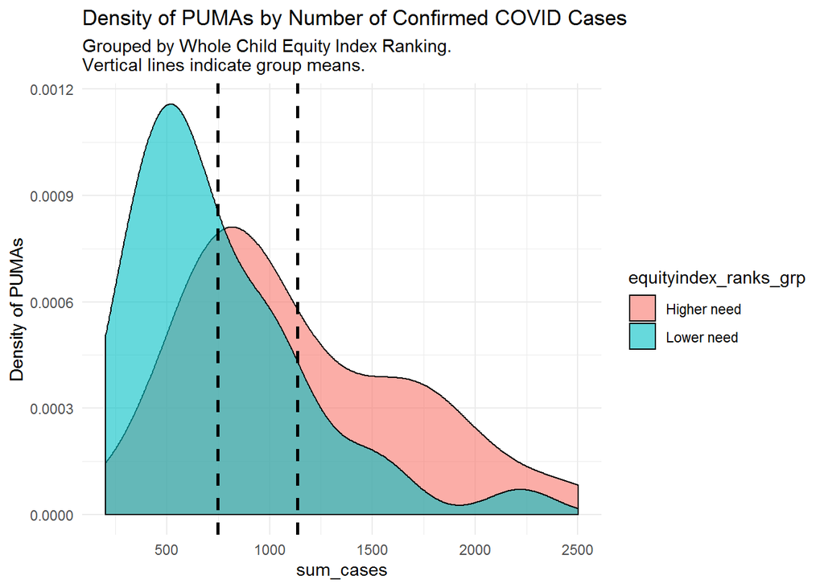

```r
ggplot(wc_covid, aes(sum_cases)) +
  geom_density(aes(fill=equityindex_ranks_grp), alpha = 0.6)+
  geom_vline(data = dat_eqgrp, aes(xintercept = mean), linetype="dashed", size=1) +
  labs(title = "Density of PUMAs by Number of Confirmed COVID Cases",
       subtitle = "Grouped by Whole Child Equity Index Ranking.\nVertical lines indicate group means.") +
  ylab("Density of PUMAs") +
  theme_minimal()
```

- The average count of COVID cases in the highest-need PUMAs in LA County (top 50%) is 1136.6, **1.5 times higher than the average count of COVID cases in lower-need PUMAs.**

Using median of equity ranks basically shows as the same as high/highest vs. low/lowest, but with the moderate pumas muddling the story a bit.

### Typology Test 3: Equity ranks by quartile

Classify equity ranks by quartile

```r
wc_covid <-
  wc_covid %>%
  ungroup() %>%
  mutate(eqind_quart = ntile(equityindex_ranks, 4))

table(wc_covid$eqind_quart, useNA = "always")
```

```
##
##    1    2    3    4 <NA>
##   18   17   17   17    0
```

```r
table(wc_covid$eqind_quart, wc_covid$quintiles, useNA = "always")
```

```
##
##         1  2  3  4  5 <NA>
##   1    18  0  0  0  0    0
##   2     8  9  0  0  0    0
##   3     0  3 14  0  0    0
##   4     0  0  0 13  4    0
##   <NA>  0  0  0  0  0    0
```

Maybe won’t use quartiles of equity index ranks…seems like we already have the typology from the source data (quintiles), and quartiles of the equity ranks means that some 2nd quintle (high need) PUMAs get grouped in with the third quartile of equity ranks..which doesn’t seem good/no reason to reclassify already classified pumas?

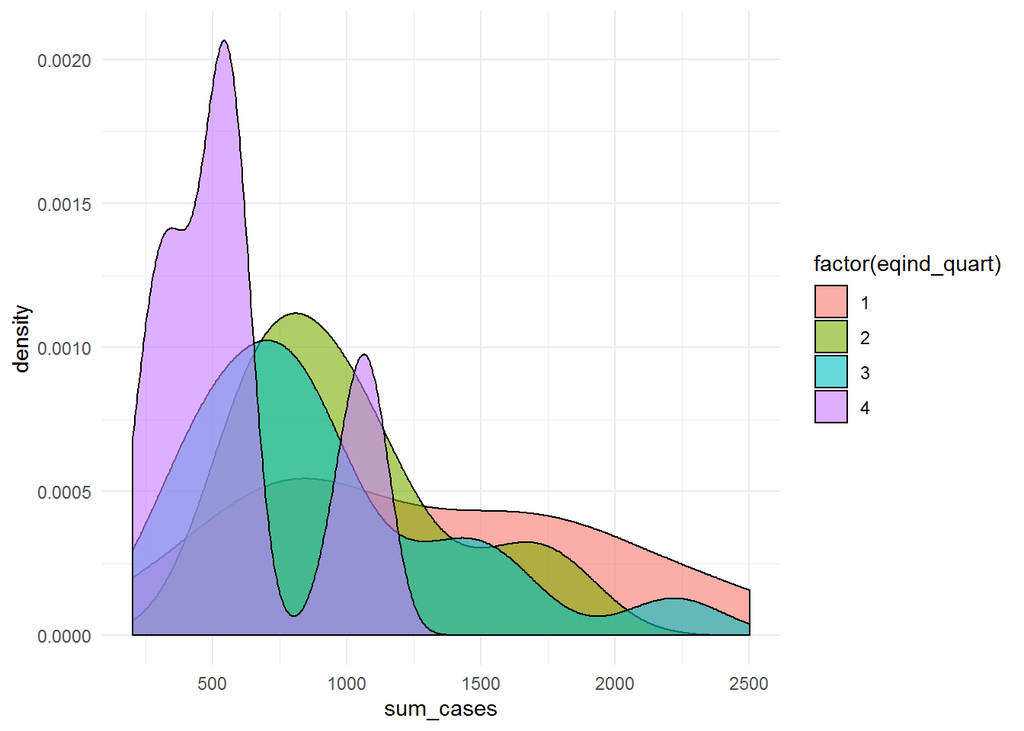

```r
ggplot(wc_covid, aes(sum_cases)) +
  geom_density(aes(fill=factor(eqind_quart)), alpha = 0.6)+
  theme_minimal()
```

^^ I don’t think this plot is good.

```r
### Typology Test 4: Quartiles of COVID Cases?

#* Would this make sense? The WC quintiles wouldn't make as much sense to be combined in some sorta of metric..

test <-
wc_covid %>%
  mutate(covid_quart = ntile(sum_cases, 4),
         equityindex_ranks_rev = (max(equityindex_ranks) + 1) - equityindex_ranks,
         label = gsub("Los Angeles County ", "", name10),
         label =gsub("Los Angeles County--", "", label))

# note higher covid quartile--higher covid case number
table(test$covid_quart, test$rankingtype)
```

```
##
##     High Highest Low Lowest Moderate
##   1    1       2   9      2        4
##   2    5       6   1      1        4
##   3    2       7   3      1        4
##   4    4      11   0      0        2
```

- actually what plot would make sense here?

### Typology Test 4–Scatter Plot:

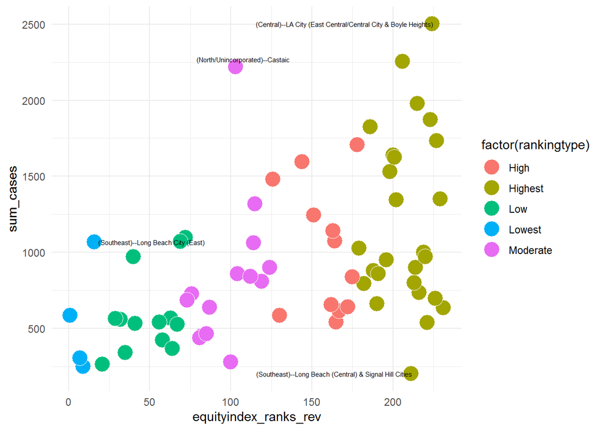

```r
library(ggrepel)

ggplot(test,
      aes(x= equityindex_ranks_rev, y=sum_cases)) +
  geom_point(colour="white", shape=21, size=6,
             aes(fill=factor(rankingtype))) +
  geom_text_repel(data = test[test$pumace10 %in% c("03701","03765", "03744", "03769"),],
                  aes(label=test[test$pumace10 %in% c("03701","03765", "03744", "03769"),]$label),  size = 2)+
  theme_minimal()
```

- note: I flipped the equity ranks so higher need is higher number.

```r
# not grouped
wc_covid$rankingtype_fac <- factor(wc_covid$rankingtype, ordered = TRUE,
                                   levels = c("Highest", "High", "Moderate", "Low", "Lowest"))

ggplot(wc_covid, aes(sum_cases)) +
  geom_density(aes(fill=factor(rankingtype_fac)), alpha = 0.7)
```

[output not shown]